# EDA — Mercado Laboral Colombiano

**Autores:** Andrés Parejo, Santiago Hurtado

## Introducción

El mercado laboral constituye uno de los principales indicadores del desempeño económico de un país, ya que refleja la capacidad de la economía para generar empleo y absorber la fuerza de trabajo disponible. En Colombia, el seguimiento continuo de indicadores laborales permite analizar la dinámica entre la población económicamente activa, los niveles de ocupación y el desempleo, proporcionando información clave para la formulación de políticas públicas y la toma de decisiones económicas.

El presente proyecto tiene como objetivo analizar el comportamiento del mercado laboral colombiano a partir de los indicadores mensuales publicados por el Banco de la República y producidos por el Departamento Administrativo Nacional de Estadística (DANE), correspondientes al período comprendido entre enero de 2001 y diciembre de 2025. Dichos indicadores se expresan en términos porcentuales y presentan una periodicidad mensual, lo que permite estudiar la evolución temporal del mercado laboral con un alto nivel de detalle.

El conjunto de datos empleado incluye variables fundamentales como la **tasa global de participación**, la **tasa de ocupación** y la **tasa de desempleo**, tanto para el total nacional como para el agregado de las trece principales áreas metropolitanas del país. La tasa global de participación mide la proporción de la población en edad de trabajar que forma parte de la fuerza laboral, reflejando la presión ejercida sobre el mercado de trabajo. Por su parte, la tasa de ocupación representa la relación entre la población ocupada y la población en edad de trabajar, mientras que la tasa de desempleo cuantifica el porcentaje de personas desocupadas dentro de la fuerza laboral total.

Dentro de este conjunto de indicadores, se selecciona como variable objetivo la **tasa de desempleo total nacional**, debido a que este indicador sintetiza el estado general del mercado laboral y representa el resultado del equilibrio entre la oferta y la demanda de trabajo en la economía colombiana.

A partir de esta variable, se busca responder la siguiente pregunta de investigación:

> **¿Cómo ha evolucionado la tasa de desempleo en Colombia a lo largo del tiempo y qué relación presenta con otros indicadores del mercado laboral como la tasa de ocupación y la tasa global de participación?**

## 1. Importación de librerías

```python
import pandas as pd
import numpy as np
import matplotlib.pyplot as plt
import matplotlib.dates as mdates
import seaborn as sns
from scipy import stats
from scipy.stats import gaussian_kde
from statsmodels.tsa.seasonal import STL

# Estilo general
sns.set_theme(style='whitegrid')
plt.rcParams['figure.figsize'] = (10, 5)
plt.rcParams['figure.dpi'] = 100
```

## 2. Carga de datos

```python
# Ajusta la ruta al archivo según tu entorno
MLC = pd.read_excel(
    'MLC.xlsx',
    sheet_name='Series de datos',
    parse_dates=['fecha']
)

MLC.head()
```

|  | fecha | tasa_global_participacion_area | tasa_global_participacion_nacional | tasa_desempleo_area | tasa_desempleo_nacional | tasa_ocupacion_area | tasa_ocupacion_nacional |
| --- | --- | --- | --- | --- | --- | --- | --- |
| 0 | 2001-01-31 | 70.0177 | 69.053538 | 20.7176 | 16.622326 | 55.5117 | 57.575237 |
| 1 | 2001-02-28 | 70.2342 | 68.948903 | 19.5518 | 17.434206 | 56.5021 | 56.928209 |
| 2 | 2001-03-31 | 69.1487 | 68.387911 | 19.1240 | 15.811933 | 55.9247 | 57.574460 |
| 3 | 2001-04-30 | 67.7233 | 65.224009 | 17.5699 | 14.515078 | 55.8244 | 55.756693 |
| 4 | 2001-05-31 | 68.0567 | 65.406094 | 17.7675 | 14.035833 | 55.9647 | 56.225804 |

## 3. Inspección inicial del dataset

Se realiza una inspección inicial de los datos del dataset para conocer su estructura, tipos de variables y estadísticas básicas.

```python
print('=== Columnas ===')
print(MLC.columns.tolist())

print('\n=== Tipos de datos ===')
print(MLC.dtypes)

print('\n=== Dimensiones (filas, columnas) ===')
print(MLC.shape)

print('\n=== Resumen estadístico ===')
display(MLC.describe())
```

```
=== Columnas ===
['fecha', 'tasa_global_participacion_area', 'tasa_global_participacion_nacional', 'tasa_desempleo_area', 'tasa_desempleo_nacional', 'tasa_ocupacion_area', 'tasa_ocupacion_nacional']

=== Tipos de datos ===
fecha                                 datetime64[us]
tasa_global_participacion_area               float64
tasa_global_participacion_nacional           float64
tasa_desempleo_area                          float64
tasa_desempleo_nacional                      float64
tasa_ocupacion_area                          float64
tasa_ocupacion_nacional                      float64
dtype: object

=== Dimensiones (filas, columnas) ===
(300, 7)

=== Resumen estadístico ===
```

|  | fecha | tasa_global_participacion_area | tasa_global_participacion_nacional | tasa_desempleo_area | tasa_desempleo_nacional | tasa_ocupacion_area | tasa_ocupacion_nacional |
| --- | --- | --- | --- | --- | --- | --- | --- |
| count | 300 | 300.000000 | 300.000000 | 300.000000 | 300.000000 | 300.000000 | 300.000000 |
| mean | 2013-07-15 18:38:24 | 67.759280 | 65.740493 | 12.627463 | 11.612474 | 59.217590 | 58.120190 |
| min | 2001-01-31 00:00:00 | 55.088000 | 53.445600 | 7.270000 | 7.020000 | 41.658000 | 42.497100 |
| 25% | 2007-04-22 12:00:00 | 66.565228 | 64.086900 | 10.449650 | 9.735275 | 57.706275 | 56.840939 |
| 50% | 2013-07-15 12:00:00 | 67.953800 | 66.138590 | 11.730200 | 11.192750 | 59.587851 | 58.315000 |
| 75% | 2019-10-07 18:00:00 | 69.468850 | 67.482400 | 14.021275 | 12.909062 | 61.128426 | 59.960250 |
| max | 2025-12-31 00:00:00 | 72.147900 | 70.617500 | 25.788700 | 21.972000 | 64.609700 | 64.008000 |
| std | NaN | 2.224336 | 2.346308 | 3.147355 | 2.448868 | 3.097003 | 2.854977 |

### 3.1 Verificación de valores faltantes

Verificamos que no hayan datos faltantes ni casillas vacías:

```
=== Valores nulos por columna ===
fecha                                 0
tasa_global_participacion_area        0
tasa_global_participacion_nacional    0
tasa_desempleo_area                   0
tasa_desempleo_nacional               0
tasa_ocupacion_area                   0
tasa_ocupacion_nacional               0
dtype: int64
```

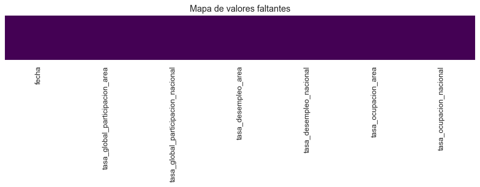

```python
print('=== Valores nulos por columna ===')
print(MLC.isnull().sum())

fig, ax = plt.subplots(figsize=(10, 4))
sns.heatmap(
    MLC.isnull(),
    cbar=False,
    yticklabels=False,
    cmap='viridis',
    ax=ax
)
ax.set_title('Mapa de valores faltantes', fontsize=13)
plt.tight_layout()
plt.show()
```

En efecto, **no encontramos ningún valor NA**. Esto nos facilita el trabajo con los datos ya que la limpieza no debe ser tan rigurosa.

## 4. Análisis de la variable objetivo: `tasa_desempleo_nacional`

Consideremos el resumen estadístico de la variable objetivo `tasa_desempleo_nacional`:

```python
col = 'tasa_desempleo_nacional'

Q1  = MLC[col].quantile(0.25)
Q3  = MLC[col].quantile(0.75)
IQR = Q3 - Q1

stats_target = pd.DataFrame([{
    'n'       : MLC[col].count(),
    'media'   : round(MLC[col].mean(), 5),
    'ds'      : round(MLC[col].std(), 5),
    'mediana' : round(MLC[col].median(), 5),
    'minimo'  : MLC[col].min(),
    'maximo'  : MLC[col].max(),
    'Q1'      : Q1,
    'Q3'      : Q3,
    'IQR'     : round(IQR, 5)
}])

display(stats_target)
```

|  | n | media | ds | mediana | minimo | maximo | Q1 | Q3 | IQR |
| --- | --- | --- | --- | --- | --- | --- | --- | --- | --- |
| 0 | 300 | 11.61247 | 2.44887 | 11.19275 | 7.02 | 21.972 | 9.735275 | 12.909062 | 3.17379 |

La variable `tasa_desempleo_nacional` fue analizada a partir de **300 observaciones**. Se obtuvo una **media de 11.61247**, que se refleja como la tasa de desempleo nacional expresada en porcentaje, donde la mitad de la muestra se encuentra por debajo de **11.19275** (mediana).

El **mínimo registrado fue de 7.02**, lo que indica que en una fecha específica se presentó una tasa de desempleo menor a la media. Por su parte, el **máximo fue de 21.972**, lo cual refleja una tasa de desempleo alta en una fecha específica.

### 4.1 Histograma con densidad, media y mediana

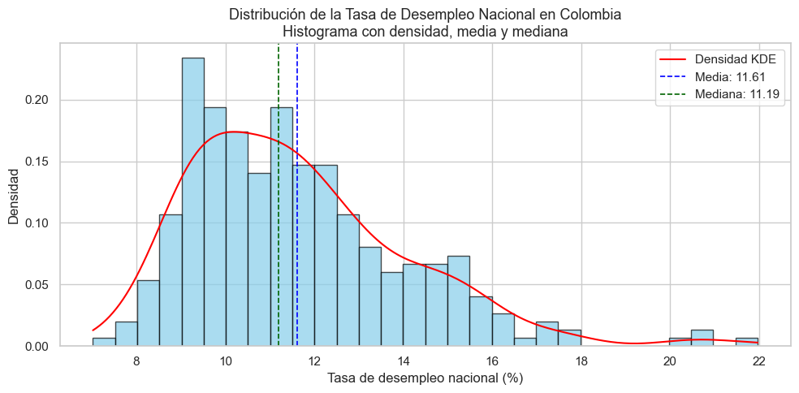

```python
media_des   = MLC[col].mean()
mediana_des = MLC[col].median()

fig, ax = plt.subplots()

# Histograma normalizado (densidad)
ax.hist(
    MLC[col], bins=30,
    color='skyblue', edgecolor='black',
    alpha=0.7, density=True
)

# Curva de densidad KDE
kde_x = np.linspace(MLC[col].min(), MLC[col].max(), 200)
kde_y = gaussian_kde(MLC[col].dropna())(kde_x)
ax.plot(kde_x, kde_y, color='red', linewidth=1.5, label='Densidad KDE')

# Líneas de media y mediana
ax.axvline(media_des,   color='blue',      linestyle='--', linewidth=1.2, label=f'Media: {media_des:.2f}')
ax.axvline(mediana_des, color='darkgreen', linestyle='--', linewidth=1.2, label=f'Mediana: {mediana_des:.2f}')

ax.set_title('Distribución de la Tasa de Desempleo Nacional en Colombia\nHistograma con densidad, media y mediana', fontsize=13)
ax.set_xlabel('Tasa de desempleo nacional (%)')
ax.set_ylabel('Densidad')
ax.legend()
plt.tight_layout()
plt.show()
```

La altura de las barras permite identificar la **concentración de los datos**. Si las frecuencias más altas se encuentran en los intervalos inferiores (cercanos a 10), predominan tasas de desempleo bajas. Por el contrario, si se concentran en valores superiores (cercanos a 20), predominan tasas altas. Este análisis visual facilita la comprensión del comportamiento del desempleo en el período estudiado y constituye una base descriptiva fundamental para estudios económicos y sociales.

### 4.2 Diagrama de caja y bigotes

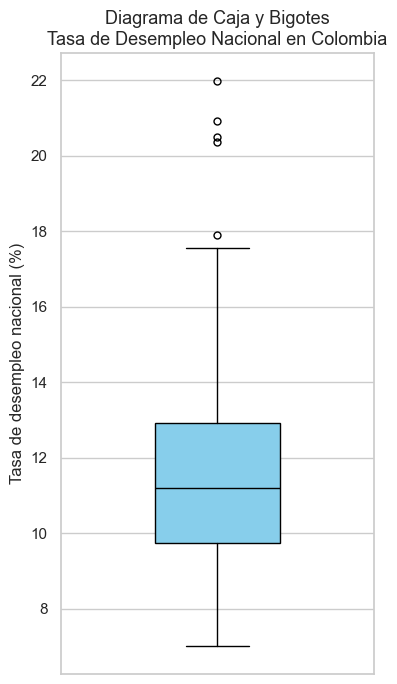

```python
fig, ax = plt.subplots(figsize=(4, 7))

bp = ax.boxplot(
    MLC[col].dropna(),
    vert=True,
    patch_artist=True,
    widths=0.4,
    boxprops=dict(facecolor='skyblue', color='black'),
    medianprops=dict(color='black'),
    flierprops=dict(marker='o', color='red', markersize=5)
)

ax.set_title('Diagrama de Caja y Bigotes\nTasa de Desempleo Nacional en Colombia', fontsize=13)
ax.set_ylabel('Tasa de desempleo nacional (%)')
ax.set_xticks([])
plt.tight_layout()
plt.show()
```

Se reflejan algunos outliers, pero al ser un dataset económico **se mantendrán por ahora**, ya que representan dinámicas reales del mercado laboral.

### 4.3 Identificación y localización de outliers en la serie temporal

Veamos dónde se ubican temporalmente los valores atípicos:

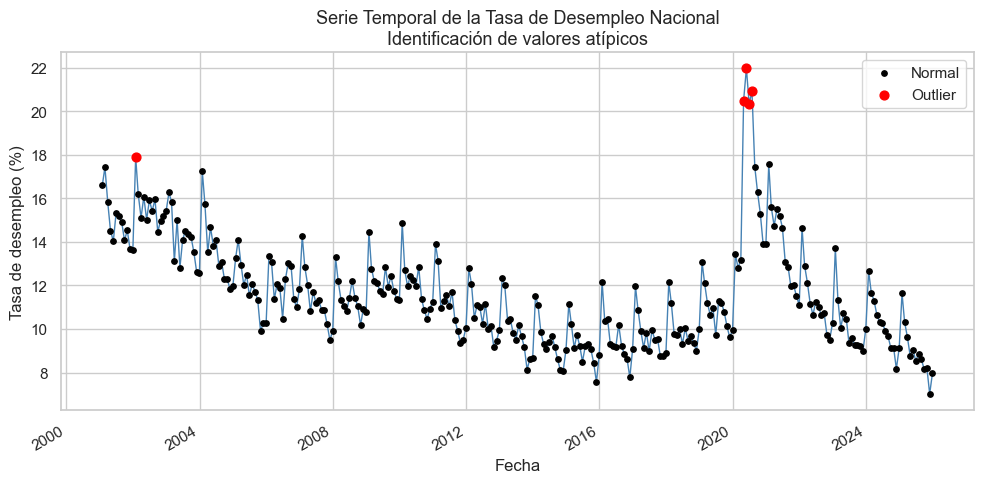

```
Total de outliers encontrados: 5
```

|  | fecha | tasa_desempleo_nacional |
| --- | --- | --- |
| 0 | 2002-01-31 | 17.909856 |
| 1 | 2020-04-30 | 20.485300 |
| 2 | 2020-05-31 | 21.972000 |
| 3 | 2020-06-30 | 20.359100 |
| 4 | 2020-07-31 | 20.914700 |

```python
Q1_o  = MLC[col].quantile(0.25)
Q3_o  = MLC[col].quantile(0.75)
IQR_o = Q3_o - Q1_o

lim_inf = Q1_o - 1.5 * IQR_o
lim_sup = Q3_o + 1.5 * IQR_o

MLC['outlier'] = MLC[col].apply(
    lambda x: 'Outlier' if (x < lim_inf or x > lim_sup) else 'Normal'
)

outliers = MLC[MLC['outlier'] == 'Outlier']
normales = MLC[MLC['outlier'] == 'Normal']

fig, ax = plt.subplots()

ax.plot(MLC['fecha'], MLC[col], color='steelblue', linewidth=1, zorder=1)
ax.scatter(normales['fecha'], normales[col], color='black', s=15, zorder=2, label='Normal')
ax.scatter(outliers['fecha'], outliers[col], color='red',   s=40, zorder=3, label='Outlier')

ax.set_title('Serie Temporal de la Tasa de Desempleo Nacional\nIdentificación de valores atípicos', fontsize=13)
ax.set_xlabel('Fecha')
ax.set_ylabel('Tasa de desempleo (%)')
ax.legend()
ax.xaxis.set_major_formatter(mdates.DateFormatter('%Y'))
fig.autofmt_xdate()
plt.tight_layout()
plt.show()

print(f'Total de outliers encontrados: {len(outliers)}')
display(outliers[['fecha', col]].reset_index(drop=True))
```

La serie temporal evidencia la evolución del desempleo en Colombia a lo largo del tiempo. Los **valores atípicos identificados** corresponden a períodos de choque económico significativo, reflejando incrementos excepcionales en la tasa de desempleo. **Estos valores no fueron eliminados** debido a que representan dinámicas reales del mercado laboral.

## 5. Análisis de las variables características

A continuación se presenta el resumen estadístico de las variables numéricas del dataset distintas a la variable objetivo:

```python
variables = [
    'tasa_global_participacion_area',
    'tasa_global_participacion_nacional',
    'tasa_desempleo_area',
    'tasa_ocupacion_area',
    'tasa_ocupacion_nacional'
]

resumen = pd.DataFrame(index=variables)
resumen['n']       = MLC[variables].count()
resumen['media']   = MLC[variables].mean().round(5)
resumen['ds']      = MLC[variables].std().round(5)
resumen['mediana'] = MLC[variables].median().round(5)
resumen['minimo']  = MLC[variables].min()
resumen['maximo']  = MLC[variables].max()
resumen['Q1']      = MLC[variables].quantile(0.25)
resumen['Q3']      = MLC[variables].quantile(0.75)
resumen['IQR']     = resumen['Q3'] - resumen['Q1']
resumen.index.name = 'variable'

display(resumen.reset_index())
```

|  | variable | n | media | ds | mediana | minimo | maximo | Q1 | Q3 | IQR |
| --- | --- | --- | --- | --- | --- | --- | --- | --- | --- | --- |
| 0 | tasa_global_participacion_area | 300 | 67.75928 | 2.22434 | 67.95380 | 55.0880 | 72.1479 | 66.565228 | 69.468850 | 2.903622 |
| 1 | tasa_global_participacion_nacional | 300 | 65.74049 | 2.34631 | 66.13859 | 53.4456 | 70.6175 | 64.086900 | 67.482400 | 3.395500 |
| 2 | tasa_desempleo_area | 300 | 12.62746 | 3.14736 | 11.73020 | 7.2700 | 25.7887 | 10.449650 | 14.021275 | 3.571625 |
| 3 | tasa_ocupacion_area | 300 | 59.21759 | 3.09700 | 59.58785 | 41.6580 | 64.6097 | 57.706275 | 61.128426 | 3.422151 |
| 4 | tasa_ocupacion_nacional | 300 | 58.12019 | 2.85498 | 58.31500 | 42.4971 | 64.0080 | 56.840939 | 59.960250 | 3.119311 |

### 5.1 Boxplots por indicador del mercado laboral

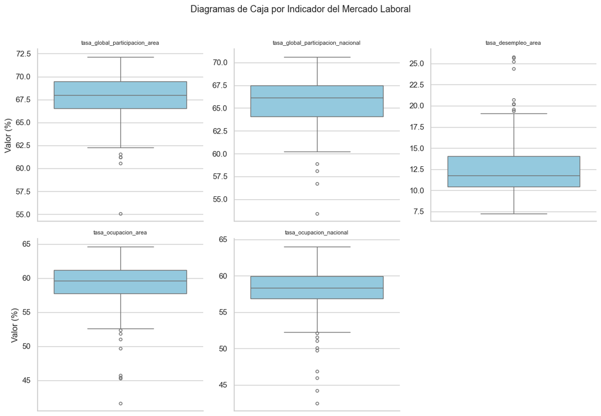

```python
MLC_long = MLC[variables].melt(var_name='variable', value_name='valor')

g = sns.FacetGrid(
    MLC_long, col='variable',
    col_wrap=3, sharey=False,
    height=4
)
g.map_dataframe(
    sns.boxplot,
    y='valor',
    color='skyblue',
    flierprops=dict(marker='o', color='red', markersize=4)
)
g.set_axis_labels('', 'Valor (%)')
g.set_titles(col_template='{col_name}', size=8)
g.figure.suptitle('Diagramas de Caja por Indicador del Mercado Laboral', y=1.02, fontsize=13)
plt.tight_layout()
plt.show()
```

## 6. Análisis bivariado

### 6.1 Matriz de correlaciones de Pearson

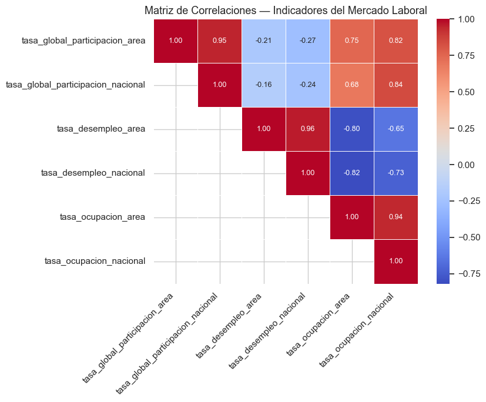

```python
cols_corr = [
    'tasa_global_participacion_area',
    'tasa_global_participacion_nacional',
    'tasa_desempleo_area',
    'tasa_desempleo_nacional',
    'tasa_ocupacion_area',
    'tasa_ocupacion_nacional'
]

matriz_cor = MLC[cols_corr].corr(method='pearson')


mask = np.tril(np.ones_like(matriz_cor, dtype=bool), k=-1)

fig, ax = plt.subplots(figsize=(9, 7))
sns.heatmap(
    matriz_cor,
    mask=mask,
    annot=True, fmt='.2f',
    cmap='coolwarm',
    square=True,
    linewidths=0.5,
    annot_kws={'size': 9},
    ax=ax
)
ax.set_title('Matriz de Correlaciones — Indicadores del Mercado Laboral', fontsize=13)
plt.xticks(rotation=45, ha='right')
plt.tight_layout()
plt.show()
```

Al examinar la matriz de correlaciones, se identifican **relaciones clave en el mercado laboral**:

- Destaca una **alta correlación positiva** entre las tasas de desempleo de área y nacional **(0.96)**, así como entre las tasas de ocupación de ambos niveles **(0.94)**, lo que indica que los comportamientos locales y nacionales tienden a moverse de manera sincronizada.
- Asimismo, la participación global muestra una **fuerte consistencia entre el área y la nación (0.95)**.
- Por otro lado, se observa una **correlación negativa significativa** entre la tasa de desempleo y la tasa de ocupación (aproximadamente **-0.80** en ambos niveles), lo que refleja la relación inversa esperada: a mayor desempleo, menor ocupación.
- Finalmente, la participación global presenta una **correlación moderada a alta con la ocupación** (alrededor de 0.80), sugiriendo que una mayor participación en el mercado laboral se asocia con mayores niveles de ocupación, aunque su relación con el desempleo es débil y negativa.

### 6.2 Gráficos de dispersión con regresión lineal

Tomemos las variables en el gráfico de dispersión como:

- **TON**: Tasa de ocupación nacional
- **TDN**: Tasa de desempleo nacional
- **TGPN**: Tasa global de participación nacional
- **TDA**: Tasa de desempleo área

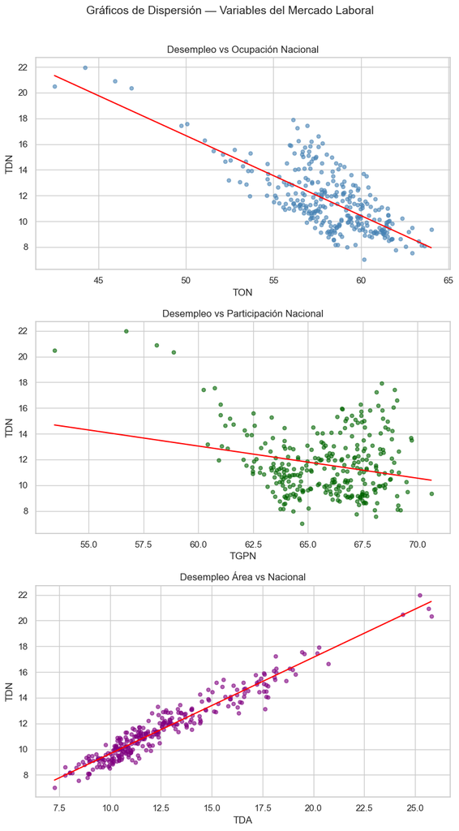

```python
fig, axes = plt.subplots(3, 1, figsize=(8, 14))

# --- G1: Desempleo vs Ocupación Nacional ---
axes[0].scatter(
    MLC['tasa_ocupacion_nacional'],
    MLC['tasa_desempleo_nacional'],
    color='steelblue', alpha=0.6, s=20
)
m1, b1, *_ = stats.linregress(
    MLC['tasa_ocupacion_nacional'].dropna(),
    MLC['tasa_desempleo_nacional'].dropna()
)
x1 = np.linspace(MLC['tasa_ocupacion_nacional'].min(), MLC['tasa_ocupacion_nacional'].max(), 100)
axes[0].plot(x1, m1*x1 + b1, color='red')
axes[0].set_title('Desempleo vs Ocupación Nacional')
axes[0].set_xlabel('TON')
axes[0].set_ylabel('TDN')

# --- G2: Desempleo vs Participación Nacional ---
axes[1].scatter(
    MLC['tasa_global_participacion_nacional'],
    MLC['tasa_desempleo_nacional'],
    color='darkgreen', alpha=0.6, s=20
)
m2, b2, *_ = stats.linregress(
    MLC['tasa_global_participacion_nacional'].dropna(),
    MLC['tasa_desempleo_nacional'].dropna()
)
x2 = np.linspace(MLC['tasa_global_participacion_nacional'].min(), MLC['tasa_global_participacion_nacional'].max(), 100)
axes[1].plot(x2, m2*x2 + b2, color='red')
axes[1].set_title('Desempleo vs Participación Nacional')
axes[1].set_xlabel('TGPN')
axes[1].set_ylabel('TDN')

# --- G3: Desempleo Área vs Nacional ---
axes[2].scatter(
    MLC['tasa_desempleo_area'],
    MLC['tasa_desempleo_nacional'],
    color='purple', alpha=0.6, s=20
)
m3, b3, *_ = stats.linregress(
    MLC['tasa_desempleo_area'].dropna(),
    MLC['tasa_desempleo_nacional'].dropna()
)
x3 = np.linspace(MLC['tasa_desempleo_area'].min(), MLC['tasa_desempleo_area'].max(), 100)
axes[2].plot(x3, m3*x3 + b3, color='red')
axes[2].set_title('Desempleo Área vs Nacional')
axes[2].set_xlabel('TDA')
axes[2].set_ylabel('TDN')

plt.suptitle('Gráficos de Dispersión — Variables del Mercado Laboral', fontsize=14, y=1.01)
plt.tight_layout()
plt.show()
```

### 6.3 Evolución temporal: Desempleo vs Ocupación Nacional

Analizamos la variable objetivo respecto a la ocupación, donde se refleja:

- Cuando la **ocupación sube** → el **desempleo baja**
- Comportamiento inverso del mercado laboral

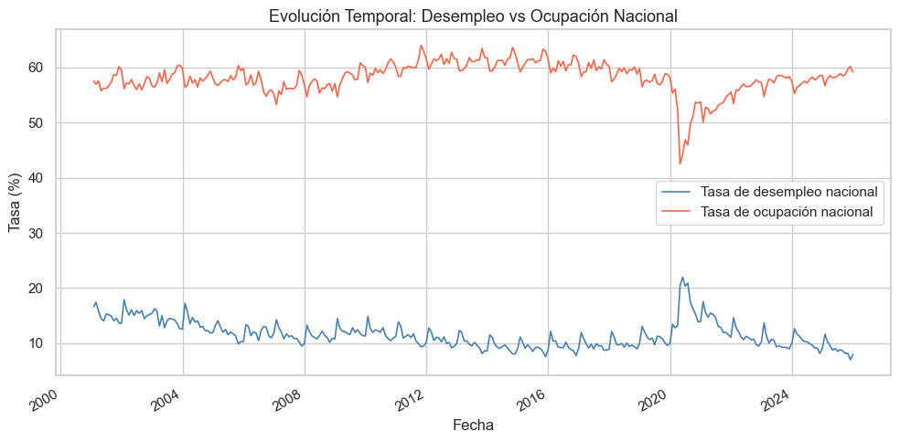

```python
fig, ax = plt.subplots()

ax.plot(MLC['fecha'], MLC['tasa_desempleo_nacional'],
        color='steelblue', linewidth=1.2, label='Tasa de desempleo nacional')
ax.plot(MLC['fecha'], MLC['tasa_ocupacion_nacional'],
        color='tomato', linewidth=1.2, label='Tasa de ocupación nacional')

ax.set_title('Evolución Temporal: Desempleo vs Ocupación Nacional', fontsize=13)
ax.set_xlabel('Fecha')
ax.set_ylabel('Tasa (%)')
ax.legend()
ax.xaxis.set_major_formatter(mdates.DateFormatter('%Y'))
fig.autofmt_xdate()
plt.tight_layout()
plt.show()
```

Al observar la evolución temporal del mercado laboral nacional entre los años 2000 y 2025, se identifican **dinámicas inversas y claramente definidas** entre el desempleo y la ocupación.

Esta gráfica valida visualmente la correlación negativa observada en análisis anteriores y permite identificar con claridad los momentos de **mayor tensión en el mercado laboral** a lo largo de las últimas dos décadas.

## 7. Descomposición temporal STL de la Tasa de Desempleo Nacional

La descomposición temporal nos permite identificar los **componentes estructurales** de la tasa de desempleo nacional: tendencia, estacionalidad y residual.

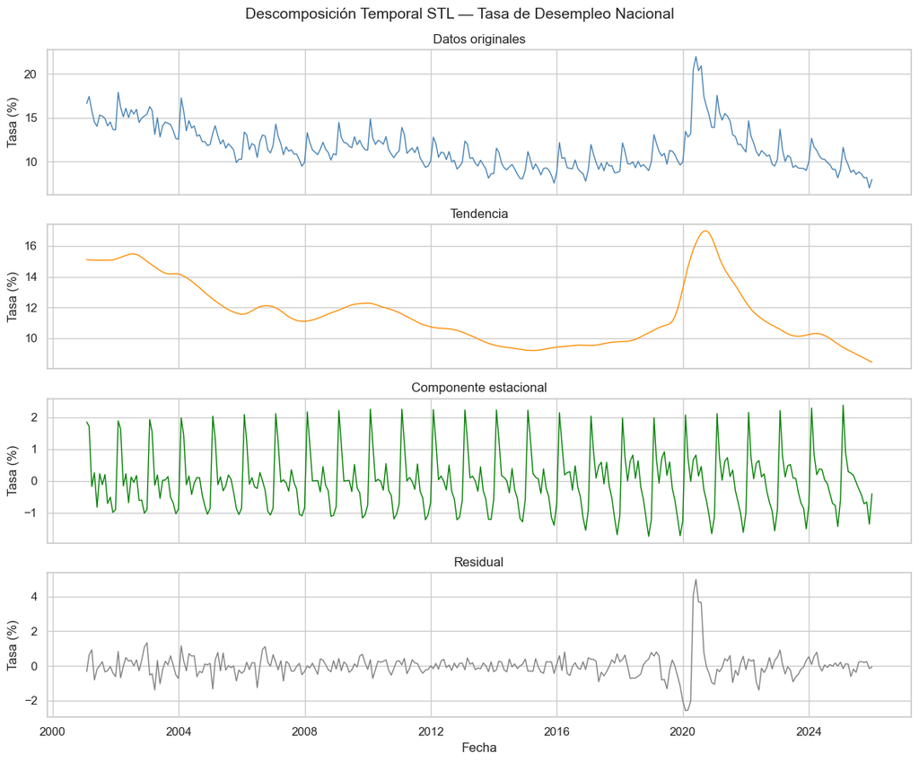

```python
# Crear serie temporal con índice mensual
ts_desempleo = (
    MLC
    .set_index('fecha')['tasa_desempleo_nacional']
    .resample('ME')
    .mean()
)

stl = STL(ts_desempleo, period=12, seasonal=13)
result = stl.fit()

fig, axes = plt.subplots(4, 1, figsize=(12, 10), sharex=True)

axes[0].plot(ts_desempleo, color='steelblue', linewidth=1)
axes[0].set_title('Datos originales')
axes[0].set_ylabel('Tasa (%)')

axes[1].plot(result.trend, color='darkorange', linewidth=1)
axes[1].set_title('Tendencia')
axes[1].set_ylabel('Tasa (%)')

axes[2].plot(result.seasonal, color='green', linewidth=1)
axes[2].set_title('Componente estacional')
axes[2].set_ylabel('Tasa (%)')

axes[3].plot(result.resid, color='gray', linewidth=1)
axes[3].set_title('Residual')
axes[3].set_ylabel('Tasa (%)')
axes[3].set_xlabel('Fecha')

fig.suptitle('Descomposición Temporal STL — Tasa de Desempleo Nacional', fontsize=14)
plt.tight_layout()
plt.show()
```

Al aplicar la descomposición temporal a la tasa de desempleo nacional, podemos distinguir claramente sus tres componentes fundamentales: